# timeseries

Ayodeji Akiwowo

25 October 2017

# Time Series Analysis

## A look at Facebook’s Prophet and Forecast

This comparison is sourced from [“Data Science for Business - Time Series Forecasting”](https://shiring.github.io/forecasting/2017/06/13/retail_forcasting_part3) website

** Dataset ** The data used is the Online Retail Dataset from the UCI Machine Learning Repository. It is a transactional data set which contains all the transactions occurring between 01/12/2010 and 09/12/2011 for a UK-based and registered non-store online retail.

No of observations: 541909

No of features: 8

Features: * InvoiceNo: Invoice number uniquely assigned to each transaction. If this code starts with letter ‘c’, it indicates a cancellation.

- StockCode: Product (item) code uniquely assigned to each distinct product.
- Description: Product (item) name.
- Quantity: The quantities of each product (item) per transaction.
- InvoiceDate: Invoice Date and time, the day and time when each transaction was generated.
- UnitPrice: Unit price. Product price per unit in sterling.
- CustomerID: Customer number uniquely assigned to each customer.
- Country: Country name. The name of the country where each customer resides.

**Loading libraries**

## Read in Data

The data was read in using read_csv which allows definition of formats for each variable. Additional variables for the day, time and month were created including income and income_return using dplyr’s *mutate()*

```r
retail <- read_csv("data/onlineretail.csv",
                   col_types = cols(
                      InvoiceNo = col_character(),
                      StockCode = col_character(),
                      Description = col_character(),
                      Quantity = col_integer(),
                      InvoiceDate = col_datetime("%d/%m/%Y %H:%M"),
                      UnitPrice = col_double(),
                      CustomerID = col_integer(),
                      Country = col_character()
                      )) %>%
  mutate(day = parse_date(format(InvoiceDate, "%Y-%m-%d")),
         day_of_week = wday(day, label = TRUE),
         time = parse_time(format(InvoiceDate, "%H:%M")),
         month = format(InvoiceDate, "%m"),
         income = Quantity * UnitPrice,
         income_return = ifelse(Quantity > 0, "income", "return"))
```

```r
head(retail)
```

```
## # A tibble: 6 x 14
##   InvoiceNo StockCode                         Description Quantity
##       <chr>     <chr>                               <chr>    <int>
## 1    536365    85123A  WHITE HANGING HEART T-LIGHT HOLDER        6
## 2    536365     71053                 WHITE METAL LANTERN        6
## 3    536365    84406B      CREAM CUPID HEARTS COAT HANGER        8
## 4    536365    84029G KNITTED UNION FLAG HOT WATER BOTTLE        6
## 5    536365    84029E      RED WOOLLY HOTTIE WHITE HEART.        6
## 6    536365     22752        SET 7 BABUSHKA NESTING BOXES        2
## # ... with 10 more variables: InvoiceDate <dttm>, UnitPrice <dbl>,
## #   CustomerID <int>, Country <chr>, day <date>, day_of_week <ord>,
## #   time <time>, month <chr>, income <dbl>, income_return <chr>
```

```r
summary(retail)
```

```
##   InvoiceNo          StockCode         Description
##  Length:541909      Length:541909      Length:541909
##  Class :character   Class :character   Class :character
##  Mode  :character   Mode  :character   Mode  :character
##
##
##
##
##     Quantity          InvoiceDate                    UnitPrice
##  Min.   :-80995.00   Min.   :2010-12-01 08:26:00   Min.   :-11062.06
##  1st Qu.:     1.00   1st Qu.:2011-03-28 11:34:00   1st Qu.:     1.25
##  Median :     3.00   Median :2011-07-19 17:17:00   Median :     2.08
##  Mean   :     9.55   Mean   :2011-07-04 13:34:57   Mean   :     4.61
##  3rd Qu.:    10.00   3rd Qu.:2011-10-19 11:27:00   3rd Qu.:     4.13
##  Max.   : 80995.00   Max.   :2011-12-09 12:50:00   Max.   : 38970.00
##
##    CustomerID       Country               day             day_of_week
##  Min.   :12346    Length:541909      Min.   :2010-12-01   Sun  : 64375
##  1st Qu.:13953    Class :character   1st Qu.:2011-03-28   Mon  : 95111
##  Median :15152    Mode  :character   Median :2011-07-19   Tues :101808
##  Mean   :15288                       Mean   :2011-07-04   Wed  : 94565
##  3rd Qu.:16791                       3rd Qu.:2011-10-19   Thurs:103857
##  Max.   :18287                       Max.   :2011-12-09   Fri  : 82193
##  NA's   :135080                                           Sat  :     0
##      time             month               income
##  Length:541909     Length:541909      Min.   :-168469.60
##  Class1:hms        Class :character   1st Qu.:      3.40
##  Class2:difftime   Mode  :character   Median :      9.75
##  Mode  :numeric                       Mean   :     17.99
##                                       3rd Qu.:     17.40
##                                       Max.   : 168469.60
##
##  income_return
##  Length:541909
##  Class :character
##  Mode  :character
##
##
##
##
```

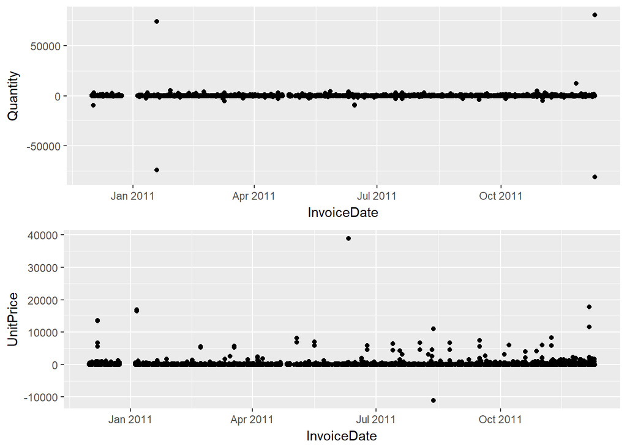

```r
p1 <- ggplot(retail, aes(InvoiceDate, Quantity)) + geom_point()
p2 <- ggplot(retail, aes(InvoiceDate, UnitPrice)) + geom_point()

grid.arrange(p1, p2)
```

```r
retail %>% filter(Quantity >50000)
```

```
## # A tibble: 2 x 14
##   InvoiceNo StockCode                    Description Quantity
##       <chr>     <chr>                          <chr>    <int>
## 1    541431     23166 MEDIUM CERAMIC TOP STORAGE JAR    74215
## 2    581483     23843    PAPER CRAFT , LITTLE BIRDIE    80995
## # ... with 10 more variables: InvoiceDate <dttm>, UnitPrice <dbl>,
## #   CustomerID <int>, Country <chr>, day <date>, day_of_week <ord>,
## #   time <time>, month <chr>, income <dbl>, income_return <chr>
```

```r
retail %>% filter(Quantity < -50000)
```

```
## # A tibble: 2 x 14
##   InvoiceNo StockCode                    Description Quantity
##       <chr>     <chr>                          <chr>    <int>
## 1   C541433     23166 MEDIUM CERAMIC TOP STORAGE JAR   -74215
## 2   C581484     23843    PAPER CRAFT , LITTLE BIRDIE   -80995
## # ... with 10 more variables: InvoiceDate <dttm>, UnitPrice <dbl>,
## #   CustomerID <int>, Country <chr>, day <date>, day_of_week <ord>,
## #   time <time>, month <chr>, income <dbl>, income_return <chr>
```

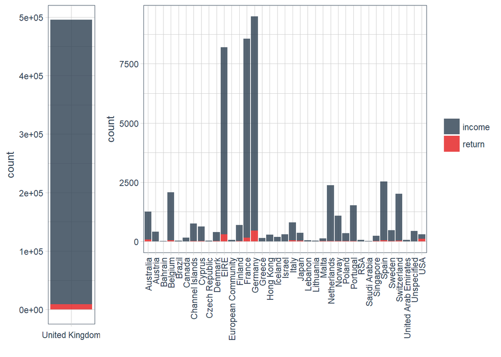

```r
p3 <- retail %>%
  filter(Country == "United Kingdom") %>%
  ggplot(aes(x = Country, fill = income_return)) +
    geom_bar(alpha = 0.8) +
    scale_fill_manual(values = palette_light()) +
    theme_tq() +
    theme(axis.text.x = element_text(angle = 0, vjust = 0, hjust = 0.5)) +
    guides(fill = FALSE) +
    labs(x = "")

p4 <- retail %>%
  filter(Country != "United Kingdom") %>%
  ggplot(aes(x = Country, fill = income_return)) +
    geom_bar(alpha = 0.8) +
    scale_fill_manual(values = palette_light()) +
    theme_tq() +
    theme(legend.position = "right") +
    theme(axis.text.x = element_text(angle = 90, vjust = 0.5, hjust = 1)) +
    labs(x = "",
         fill = "")

grid.arrange(p3, p4, widths = c(0.2, 0.8))
```

The United Kingdom has the highest number of transactions followed by Germany and France.

This is a Time Series analysis therefore, we will now focus on time series data. Earlier whilst reading the data into R, we specified that the InvoiceDate should be read in Date format hence there is no need to repeat this step.

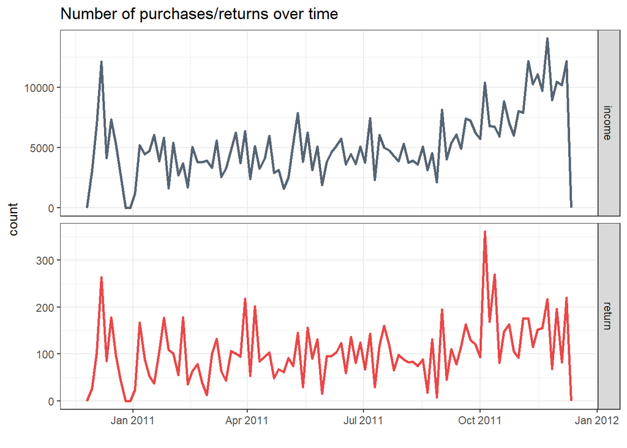

```r
retail %>%
  ggplot(aes(x = day, color = income_return)) + geom_freqpoly(bins = 100, size = 1, alpha = 0.8) +
    facet_grid(income_return ~ ., scales = "free") +
    scale_color_manual(values = palette_light()) +
    theme_bw() +
    guides(color = FALSE) +
    labs(title = "Number of purchases/returns over time",
         x = "")
```

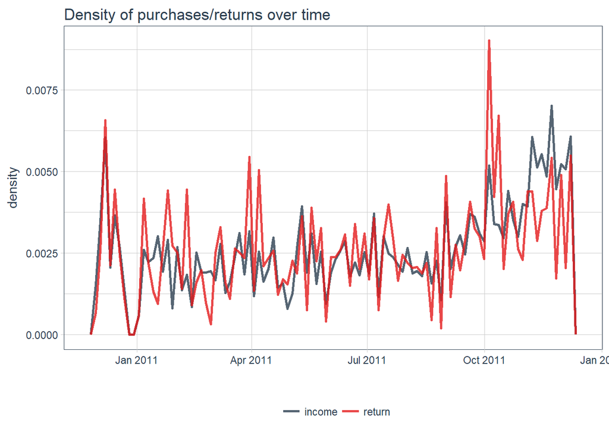

```r
retail %>%
  ggplot(aes(x = day, y = ..density.., color = income_return)) +
    geom_freqpoly(size = 1, alpha = 0.8, bins = 100) +
    scale_color_manual(values = palette_light()) +
    theme_tq() +
    labs(title = "Density of purchases/returns over time",
         x = "",
         color = "")
```

[figure not shown]

[output not shown]

```r
retail %>%
  group_by(day, income_return) %>%
  summarise(sum_income = sum(income)) %>%
  ggplot(aes(x = day, y = sum_income, color = income_return)) +
    facet_grid(income_return ~ ., scales = "free") +
    geom_ref_line(h = 0, colour = "grey") +
    geom_line(size = 1, alpha = 0.8) +
    scale_color_manual(values = palette_light()) +
    theme_tq() +
    guides(color = FALSE) +
    labs(title = "Income/loss from transactions per day",
         x = "",
         y = "sum of income/losses",
         color = "")
```

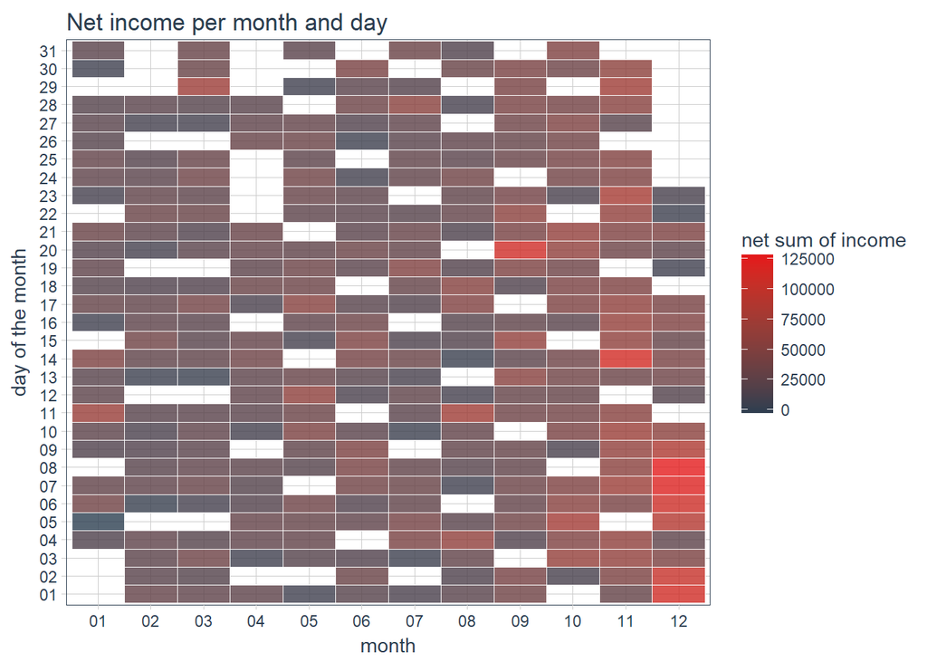

```r
retail %>%
  mutate(day2 = format(InvoiceDate, "%d")) %>%
  group_by(month, day2) %>%
  summarise(sum_income = sum(income)) %>%
  ggplot(aes(x = month, y = day2, fill = sum_income)) +
    geom_tile(alpha = 0.8, color = "white") +
    scale_fill_gradientn(colours = c(palette_light()[[1]], palette_light()[[2]])) +
    theme_tq() +
    theme(legend.position = "right") +
    labs(title = "Net income per month and day",
         y = "day of the month",
         fill = "net sum of income")
```

When we plot transactions of the day of the month against the month, we can see for each month, what days are active. For example, in December, a lot of activity take place at the beginning of the month. We can do same to see what time of the day transactions occur.

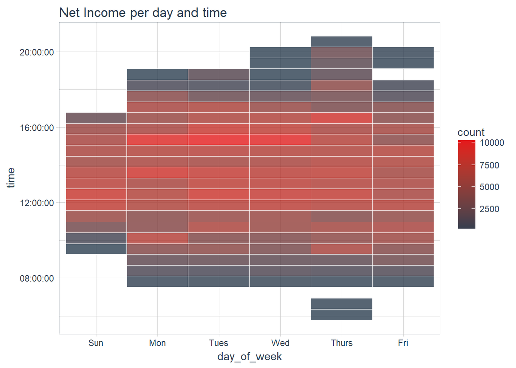

```r
retail %>%
  ggplot(aes(x = day_of_week, y = time)) +
    stat_bin2d(alpha = 0.8, bins = 25, color = "white") +
    scale_fill_gradientn(colours = c(palette_light()[[1]], palette_light()[[2]])) +
    theme_tq() +
    theme(legend.position = "right") +
    labs(title = "Net Income per day and time")
```

** Repeat Customers **

We can see from the plot below that there are over 60% repeat buyers on this dataset.

[output not shown]

[figure not shown]

```r
customer_purch <- retail %>%
  group_by(day, CustomerID) %>%
  summarise(n = n(),
            sum_it = sum(Quantity),
            sum_in = sum(income)) %>%
  group_by(day) %>%
  summarise(mean_in_cust = mean(sum_in),
            mean_quant_cust = mean(sum_it),
            mean_items_cust = mean(n))
```

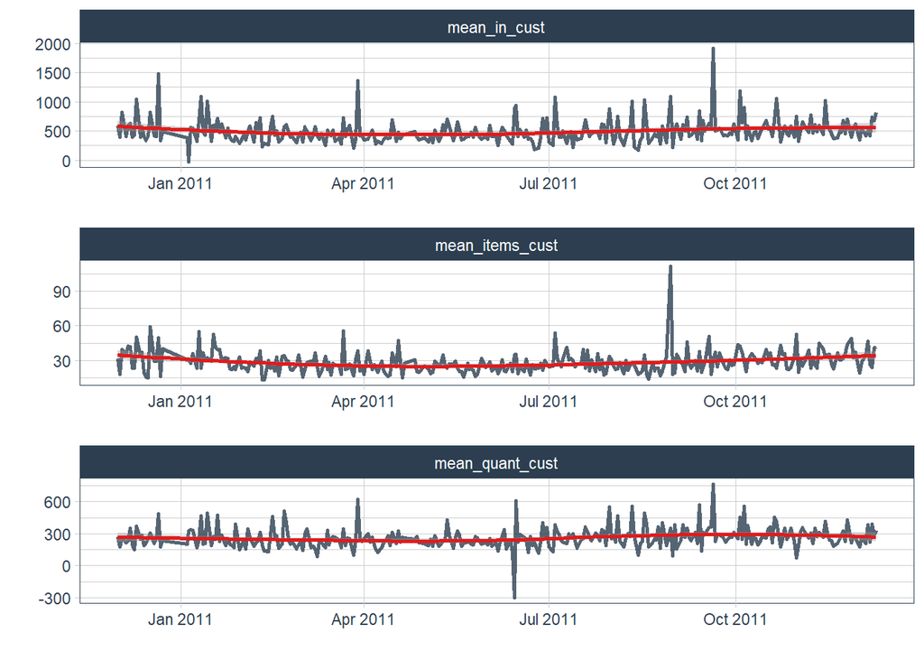

```r
customer_purch %>%
  gather(x, y, mean_in_cust:mean_items_cust) %>%
  ggplot(aes(x = day, y = y)) +
    facet_wrap(~ x, ncol = 1, scales = "free") +
    geom_line(color = palette_light()[[1]], size = 1, alpha = 0.8) +
    geom_smooth(color = palette_light()[[2]], method = 'loess') +
    theme_tq() +
    labs(x = "",
         y = "")
```

** Create Features **

```r
most_sold <- retail %>%
  group_by(day, StockCode, Description) %>%
  summarise(sum = sum(Quantity)) %>%
  group_by(StockCode, Description) %>%
  summarise(n = n()) %>%
  arrange(-n)
```

```r
income <- retail %>%
  group_by(day) %>%
  summarise(sum_income = sum(income),
            mean_income = mean(income),
            sum_quantity = sum(Quantity),
            mean_quantity = mean(Quantity))
```

```r
purchases <- retail %>%
  filter(income > 0) %>%
  group_by(day) %>%
  summarise(sum_income_purch = sum(income),
            mean_income_purch = mean(income),
            sum_quantity_purch = sum(Quantity),
            mean_quantity_purch = mean(Quantity))
```

```r
returns <- retail %>%
  filter(income < 0) %>%
  group_by(day) %>%
  summarise(sum_income_return = sum(income),
            mean_income_return = mean(income),
            sum_quantity_return = sum(Quantity),
            mean_quantity_return = mean(Quantity))
```

```r
temp <- distinct(select(retail, day, StockCode, UnitPrice)) %>%
  mutate(temp = paste(day, StockCode, sep = "_")) %>%
  select(temp, UnitPrice)

mean_unit_price <- retail %>%
  filter(income_return == "income") %>%
  group_by(day, StockCode) %>%
  summarise(n = n()) %>%
  mutate(temp = paste(day, StockCode, sep = "_")) %>%
  left_join(temp, by = "temp") %>%
  group_by(day, StockCode) %>%
  summarise(mean = mean(UnitPrice)) %>%
  group_by(day) %>%
  summarise(mean_unit_price = mean(mean))
```

```r
most_sold_day <- retail %>%
  filter(StockCode %in% most_sold$StockCode[1:10]) %>%
  group_by(day, StockCode) %>%
  summarise(sum = sum(Quantity)) %>%
  spread(key = StockCode, value = sum)
```

```r
income_return <- retail %>%
  group_by(day, income_return) %>%
  summarise(sum = sum(Quantity)) %>%
  spread(key = income_return, value = sum)
```

```r
country_purch <- retail %>%
  mutate(Country2 = ifelse(Country == "United Kingdom", "uk", "other_country")) %>%
  group_by(day, Country2) %>%
  summarise(sum = sum(Quantity)) %>%
  spread(key = Country2, value = sum) %>%
  mutate(prop_other_country = other_country / sum(other_country + uk),
         prop_uk = uk / sum(other_country + uk))
```

```r
n_items <- retail %>%
  group_by(day, StockCode) %>%
  summarise(n = n()) %>%
  group_by(day) %>%
  summarise(n_items = n())
```

```r
retail_p_day <- distinct(select(retail, day, day_of_week, month)) %>%
  left_join(income, by = "day") %>%
  left_join(mean_unit_price, by = "day") %>%
  left_join(purchases, by = "day") %>%
  left_join(returns, by = "day") %>%
  left_join(customer_purch, by = "day") %>%
  left_join(rep_customer_day, by = "day") %>%
  left_join(income_return, by = "day") %>%
  left_join(country_purch, by = "day") %>%
  left_join(n_items, by = "day") %>%
  left_join(most_sold_day, by = "day") %>%
  mutate(diff_sum_income = sum_income - lag(sum_income),
         season = ifelse(month %in% c("03", "04", "05"), "spring",
                         ifelse(month %in% c("06", "07", "08"), "summer",
                                ifelse(month %in% c("09", "10", "11"), "fall", "winter"))))
```

The additional features created will now be joined with the retail dataset to form the retail_p_day dataset. This will be used for modeling our time series.

Create a column called model and label data up to 1st of November 2011 as train and all after that as test

```r
retail_p_day <- retail_p_day %>%
  mutate(model = ifelse(day <= "2011-11-01", "train", "test"))

colnames(retail_p_day)[grep("^[0-9]+", colnames(retail_p_day))] <- paste0("P_", colnames(retail_p_day)[grep("^[0-9]+", colnames(retail_p_day))])
```

## Prophet

Prophet developers claim the default parameters are good enough to provide good predictions. Like many prediction packages, there are two steps to making a prediction:

1. build a model using the prophet() function and
2. predict future values using the model.

*prophet(df = NULL, growth = “linear”, changepoints = NULL,* *n.changepoints = 25, yearly.seasonality = “auto”,* *weekly.seasonality = “auto”, daily.seasonality = “auto”,* *holidays = NULL, seasonality.prior.scale = 10,* *holidays.prior.scale = 10, changepoint.prior.scale = 0.05,* *mcmc.samples = 0, interval.width = 0.8, uncertainty.samples = 1000,* *fit = TRUE, …)*

Plotting the training and test data:

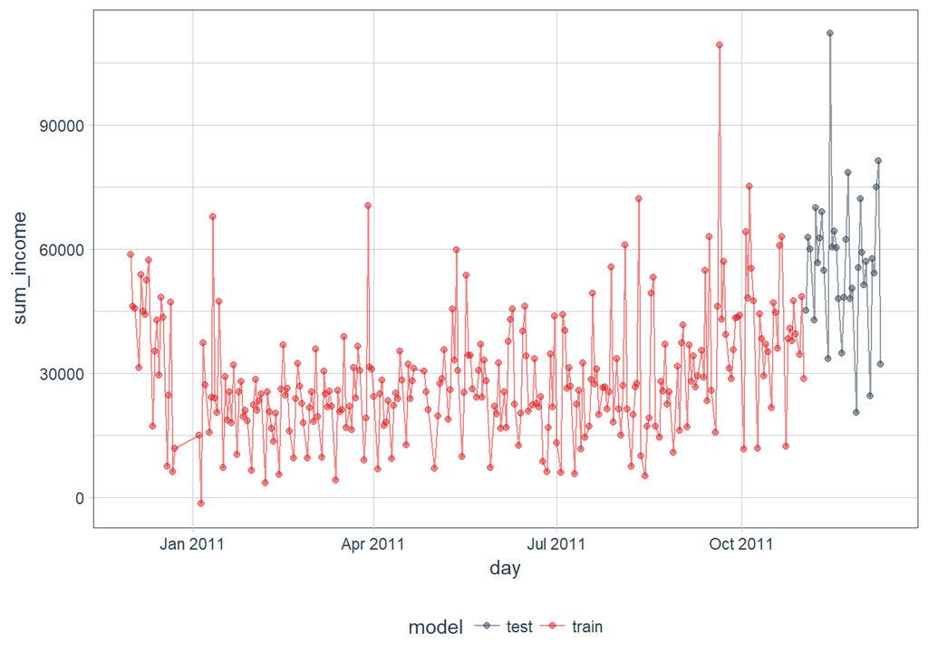

```r
retail_p_day %>%
  ggplot(aes(x = day, y = sum_income, color = model)) +
    geom_point(alpha = 0.5) +
    geom_line(alpha = 0.5) +
    scale_color_manual(values = palette_light()) +
    theme_tq()
```

Create the training and test data and remember to rename the date column as ‘ds’ as this is mandatory for pProphet to work.

```r
train <- filter(retail_p_day, model == "train") %>%
  select(day, sum_income) %>%
  rename(ds = day,
         y = sum_income)

test <- filter(retail_p_day, model == "test") %>%
  select(day, sum_income) %>%
  rename(ds = day)
```

One of Prophet’s strengths is the ability to handle missing data. In a time series data like the one we have used, there will be days when there are no transactions. I will use the missing data in the dataset as ‘holidays’

```r
off_days <- data.frame(ds = as.Date(c("2010-12-24", "2010-12-25", "2010-12-26", "2010-12-27", "2010-12-28",
                                      "2010-12-29", "2010-12-30", "2010-01-01", "2010-01-02", "2010-01-03",
                                      "2011-04-22", "2011-04-23", "2011-04-24", "2011-04-25", "2011-05-02",
                                      "2011-05-30", "2011-08-29", "2011-04-29", "2011-04-30"))) %>%
  mutate(holiday = paste0("off_day_", seq_along(1:length(ds))))
```

```r
prophet_model_test <- prophet(train,
                              growth = "linear", # growth curve trend
                              n.changepoints = 100, # Prophet automatically detects changes in trends by selecting changepoints from the data
                              yearly.seasonality = FALSE, # yearly seasonal component using Fourier series
                              weekly.seasonality = TRUE, # weekly seasonal component using dummy variables
                              holidays = off_days)
```

```
## Disabling daily seasonality. Run prophet with daily.seasonality=TRUE to override this.
```

```
## Initial log joint probability = -8.3297
## Optimization terminated normally:
##   Convergence detected: relative gradient magnitude is below tolerance
```

```r
test1 <- test[,"ds"]

future <- make_future_dataframe(prophet_model_test, periods = 33)
```

```r
forecast_test <- predict(prophet_model_test, future)
```